# R Notebook - College Admission Project Report

Organization: **Simplilearn - Master Program**  
Course: **Data Science with R**  
Project: **College Admission**  
Programming Language: **R**  
Submitted by: **Lavkush Singh**

```r
library('ggplot2')
library('dplyr')
library('caTools')
library(class)
library('ROCR')
library(e1071)
library("randomForest")
library('tidyr')
library('RColorBrewer')
library('modelr')
library('caret')
library('pROC')
getwd() # getting working directory
```

```
## [1] "C:/Users/Luvkush/Desktop/R Programming Course Project - College Admissions"
```

```r
PATH = 'E:/Simplilearn Data Science/1. Data Science with R/R_Projects'

setwd(PATH) # Setting the working directory
```

```r
options("digits" = 15) # controls the number of digits to print when printing numeric values, currently set to 15


# This is a useful function, which controls the size of the plots created.
# This function is called before creating almost every plot in this notebook.
# E.g. fig(6,4) --> This will set the width of the plot to 6 units and height as 4 units

fig <- function(width, heigth){
  options(repr.plot.width = width, repr.plot.height = heigth)
}
```

```r
college_data <- read.csv(paste(PATH,"/Datasets/College_admission.csv", sep = ""),
                         stringsAsFactors = FALSE)

head(college_data) # checking first 6 observations of data
```

```
##   admit gre  gpa ses Gender_Male Race rank
## 1     0 380 3.61   1           0    3    3
## 2     1 660 3.67   2           0    2    3
## 3     1 800 4.00   2           0    2    1
## 4     1 640 3.19   1           1    2    4
## 5     0 520 2.93   3           1    2    4
## 6     1 760 3.00   2           1    1    2
```

```r
dim(college_data) # checking the shape of the data, rows and column numbers
```

```
## [1] 400   7
```

#### Task: Find the missing values. (if any, perform missing value treatment)

```r
any(is.na(college_data)) # checking if there are any missing value in the entire dataset
```

```
## [1] FALSE
```

```r
sapply(college_data, is.null) # checking column wise missing values
```

```
##       admit         gre         gpa         ses Gender_Male        Race
##       FALSE       FALSE       FALSE       FALSE       FALSE       FALSE
##        rank
##       FALSE
```

```r
college_data %>% summarise_all(~ sum(is.na(.))) # Another way of getting missing value count per column
```

```
##   admit gre gpa ses Gender_Male Race rank
## 1     0   0   0   0           0    0    0
```

#### Task: Find the structure of the data set and if required, transform the numeric data type to factor and vice-versa.

```r
str(college_data) #viewing the structure
```

```
## 'data.frame':    400 obs. of  7 variables:
##  $ admit      : int  0 1 1 1 0 1 1 0 1 0 ...
##  $ gre        : int  380 660 800 640 520 760 560 400 540 700 ...
##  $ gpa        : num  3.61 3.67 4 3.19 2.93 3 2.98 3.08 3.39 3.92 ...
##  $ ses        : int  1 2 2 1 3 2 2 2 1 1 ...
##  $ Gender_Male: int  0 0 0 1 1 1 1 0 1 0 ...
##  $ Race       : int  3 2 2 2 2 1 2 2 1 2 ...
##  $ rank       : int  3 3 1 4 4 2 1 2 3 2 ...
```

```r
college_data_copydf <- data.frame(college_data)

college_data_copydf$Gender_Male <- as.factor(college_data_copydf$Gender_Male)
college_data_copydf$Race <- as.factor(college_data_copydf$Race)
college_data_copydf$admit <- as.factor(college_data_copydf$admit)

college_data_copydf$rank <- factor(college_data_copydf$rank,
                                   levels=c(4,3,2,1),
                                   ordered=TRUE)
college_data_copydf$ses <- factor(college_data_copydf$ses,
                                  levels=c(1,2,3),
                                  ordered=TRUE)
```

```r
str(college_data_copydf)
```

```
## 'data.frame':    400 obs. of  7 variables:
##  $ admit      : Factor w/ 2 levels "0","1": 1 2 2 2 1 2 2 1 2 1 ...
##  $ gre        : int  380 660 800 640 520 760 560 400 540 700 ...
##  $ gpa        : num  3.61 3.67 4 3.19 2.93 3 2.98 3.08 3.39 3.92 ...
##  $ ses        : Ord.factor w/ 3 levels "1"<"2"<"3": 1 2 2 1 3 2 2 2 1 1 ...
##  $ Gender_Male: Factor w/ 2 levels "0","1": 1 1 1 2 2 2 2 1 2 1 ...
##  $ Race       : Factor w/ 3 levels "1","2","3": 3 2 2 2 2 1 2 2 1 2 ...
##  $ rank       : Ord.factor w/ 4 levels "4"<"3"<"2"<"1": 2 2 4 1 1 3 4 3 2 3 ...
```

```r
summary(college_data_copydf)
```

```
##  admit        gre             gpa         ses     Gender_Male Race    rank
##  0:273   Min.   :220.0   Min.   :2.2600   1:132   0:210       1:143   4: 67
##  1:127   1st Qu.:520.0   1st Qu.:3.1300   2:139   1:190       2:129   3:121
##          Median :580.0   Median :3.3950   3:129               3:128   2:151
##          Mean   :587.7   Mean   :3.3899                               1: 61
##          3rd Qu.:660.0   3rd Qu.:3.6700
##          Max.   :800.0   Max.   :4.0000
```

#### Task: Find whether the data is normally distributed or not. Use the plot to determine the same. Normalize the data if not normally distributed.

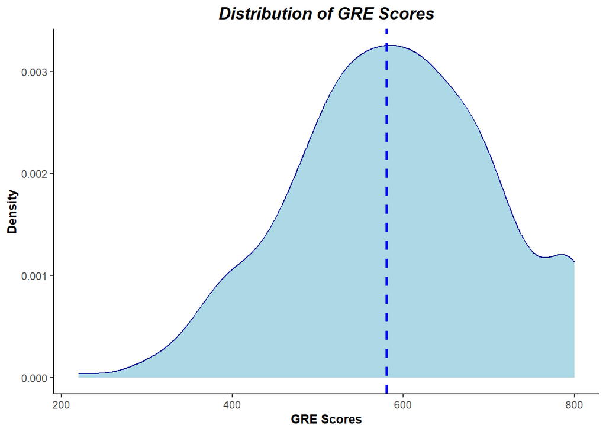

```r
# Distribution of GRE Scores - Density Curve

fig(7,4)
college_data_copydf %>%
  ggplot(aes(x = gre)) +
  geom_density(color="darkblue", fill="lightblue") +
  geom_vline(aes(xintercept=median(gre)),color="blue", linetype="dashed", linewidth=1) +
  ggtitle("Distribution of GRE Scores") +
  xlab("GRE Scores") + ylab("Density") +
  theme_classic() +
  theme(
    plot.title = element_text(color="black", size=14, face="bold.italic", hjust = 0.5),
    axis.title.x = element_text(color="black", size=10, face="bold"),
    axis.title.y = element_text(color="black", size=10, face="bold"))
```

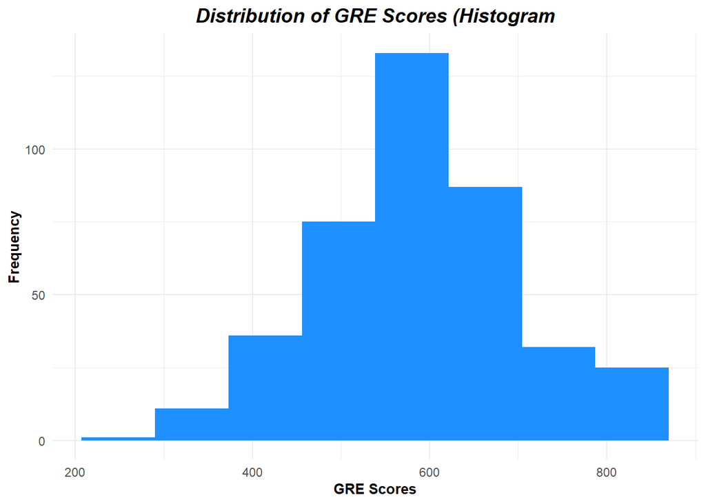

```r
# Distribution

fig(7,4.5)
college_data_copydf %>%
  ggplot(aes(x = gre)) +
  geom_histogram(bins = 8, fill = 'dodgerblue') +
  ggtitle("Distribution of GRE Scores (Histogram") +
  xlab("GRE Scores") + ylab("Frequency") +
  theme_minimal() +
  theme(
    plot.title = element_text(color="black", size=14, face="bold.italic", hjust = 0.5),
    axis.title.x = element_text(color="black", size=10, face="bold"),
    axis.title.y = element_text(color="black", size=10, face="bold"))
```

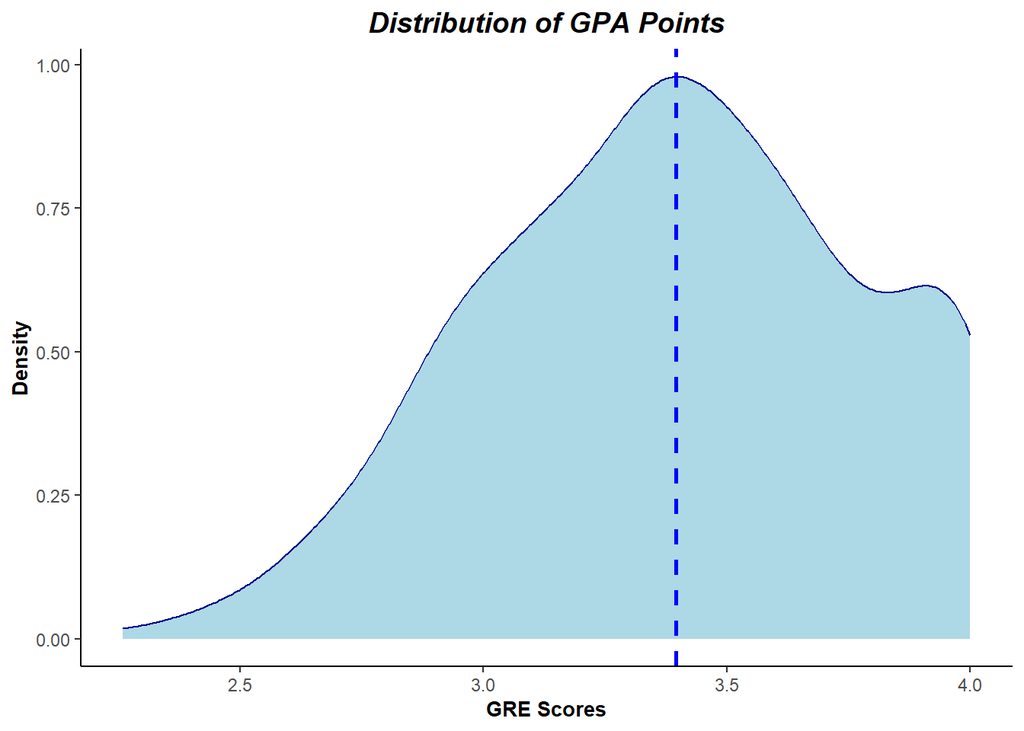

```r
# Distribution of GPA Points - Density Curve

fig(7,4)
college_data_copydf %>%
  ggplot(aes(x = gpa)) +
  geom_density(color="darkblue", fill="lightblue") +
  geom_vline(aes(xintercept=median(gpa)),color="blue", linetype="dashed", linewidth=1) +
  ggtitle("Distribution of GPA Points") +
  xlab("GRE Scores") + ylab("Density") +
  theme_classic() +
  theme(
    plot.title = element_text(color="black", size=14, face="bold.italic", hjust = 0.5),
    axis.title.x = element_text(color="black", size=10, face="bold"),
    axis.title.y = element_text(color="black", size=10, face="bold"))
```

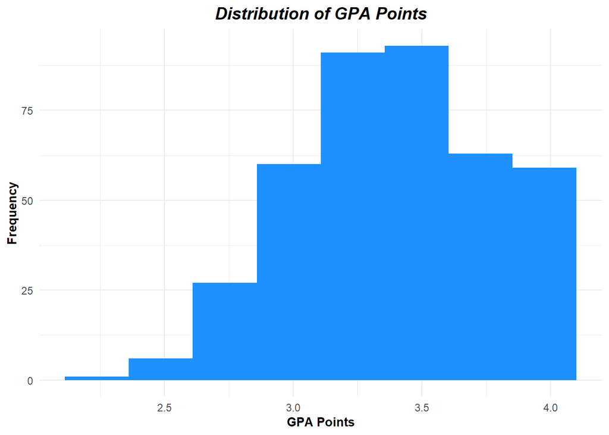

```r
fig(7,4.5)
college_data_copydf %>%
  ggplot(aes(x = gpa)) +
  geom_histogram(bins = 8, fill = 'dodgerblue') +
  ggtitle("Distribution of GPA Points") +
  xlab("GPA Points") + ylab("Frequency") +
  theme_minimal() +
  theme(
    plot.title = element_text(color="black", size=14, face="bold.italic", hjust = 0.5),
    axis.title.x = element_text(color="black", size=10, face="bold"),
    axis.title.y = element_text(color="black", size=10, face="bold"))
```

#### Task: Data Visualization and insights

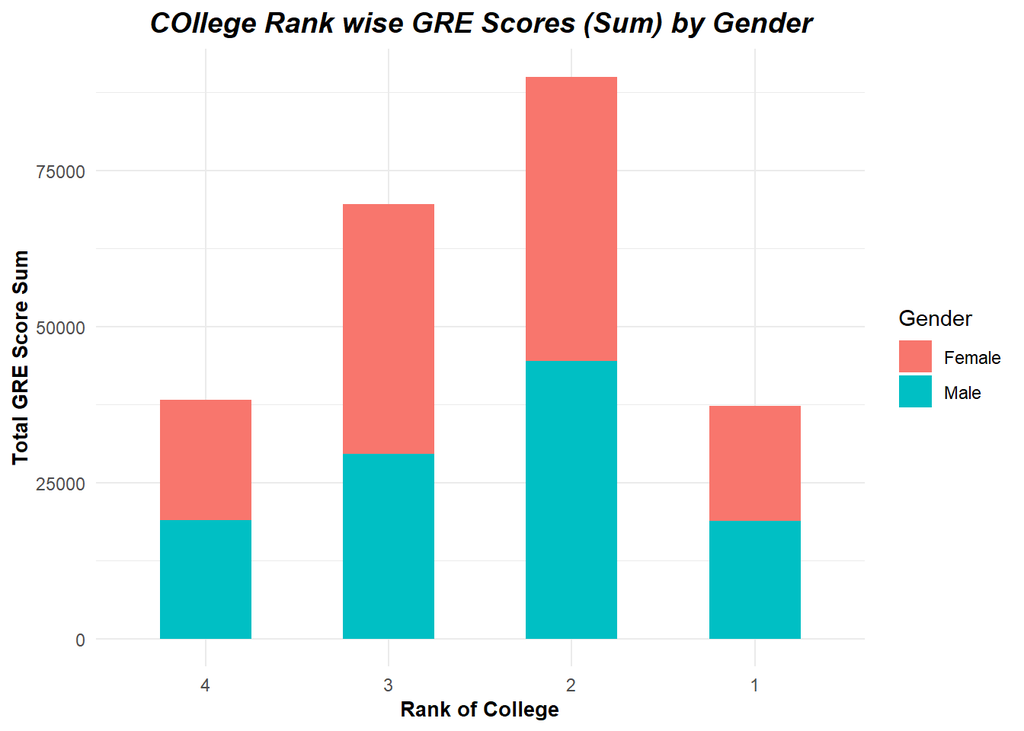

```r
# Stacked bar plot

fig(7,4)
college_data_copydf %>%
  ggplot(aes(x=rank, y = gre, fill = Gender_Male)) +
  geom_bar(width = 0.5, stat='identity') +
  labs(fill="Gender") +
  scale_fill_discrete(labels=c('Female', 'Male')) +
  ggtitle("COllege Rank wise GRE Scores (Sum) by Gender") +
  ylab("Total GRE Score Sum") + xlab("Rank of College") +
  theme_minimal() +
  theme(
    plot.title = element_text(color="black", size=14, face="bold.italic", hjust = 0.5),
    axis.title.x = element_text(color="black", size=10, face="bold"),
    axis.title.y = element_text(color="black", size=10, face="bold"))
```

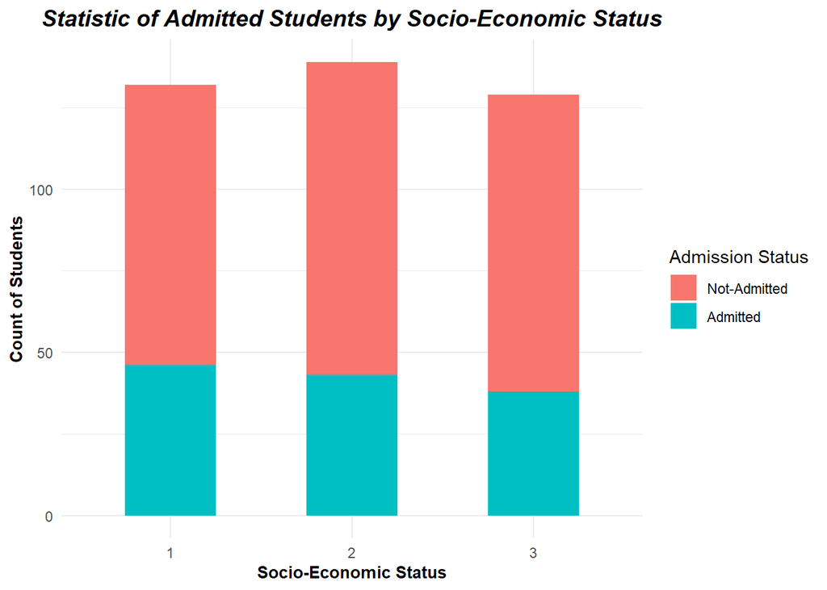

```r
fig(7,4)
college_data_copydf %>%
  ggplot(aes(x=ses, fill = admit)) +
  geom_bar(width = 0.5, stat="count") +
  labs(fill="Admission Status") +
  scale_fill_discrete(labels=c('Not-Admitted', 'Admitted')) +
  ggtitle("Statistic of Admitted Students by Socio-Economic Status") +
  ylab("Count of Students") + xlab("Socio-Economic Status") +
  theme_minimal() +
  theme(
    plot.title = element_text(color="black", size=14, face="bold.italic", hjust = 0.5),
    axis.title.x = element_text(color="black", size=10, face="bold"),
    axis.title.y = element_text(color="black", size=10, face="bold"))
```

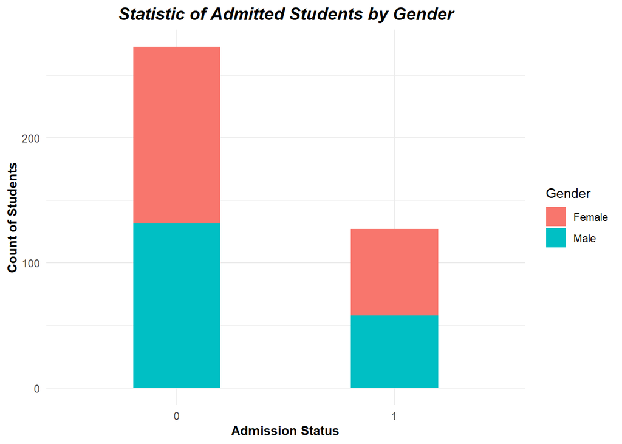

```r
fig(7,4)
college_data_copydf %>%
  ggplot(aes(x=admit, fill = Gender_Male)) +
  geom_bar(width = 0.4, stat="count") +
  labs(fill="Gender") +
  scale_fill_discrete(labels=c('Female', 'Male')) +
  ggtitle("Statistic of Admitted Students by Gender") +
  ylab("Count of Students") + xlab("Admission Status") +
  theme_minimal() +
  theme(
    plot.title = element_text(color="black", size=14, face="bold.italic", hjust = 0.5),
    axis.title.x = element_text(color="black", size=10, face="bold"),
    axis.title.y = element_text(color="black", size=10, face="bold"))
```

```r
socioeconomic_gpa_gre_stats <- college_data_copydf %>%
                              group_by(ses) %>%
                              summarise(gre = median(gre),
                                        gpa = median(gpa),
                                        .groups = 'keep')

data.frame(socioeconomic_gpa_gre_stats)
```

```
##   ses gre  gpa
## 1   1 580 3.38
## 2   2 620 3.43
## 3   3 580 3.38
```

```r
avg_genderwise_scores <- college_data_copydf %>%
                              group_by(Gender_Male) %>%
                              summarise(gre = median(gre),
                                        gpa = median(gpa),
                                        .groups = 'keep')

data.frame(avg_genderwise_scores)
```

```
##   Gender_Male gre   gpa
## 1           0 580 3.400
## 2           1 580 3.385
```

#### Task: Correlation Analysis

```r
# creating new variable 'corr_data' and storing only numeric columns into it

corr_data = college_data_copydf[,sapply(college_data_copydf, is.numeric)]
head(corr_data)
```

```
##   gre  gpa
## 1 380 3.61
## 2 660 3.67
## 3 800 4.00
## 4 640 3.19
## 5 520 2.93
## 6 760 3.00
```

```r
# creating a correlation matrix, and storing it in a new variable corr_matrix, after rounding it to 2 digits

corr_matrix <- round(cor(corr_data),2)
corr_matrix
```

```
##      gre  gpa
## gre 1.00 0.38
## gpa 0.38 1.00
```

#### Task: Outlier Detection

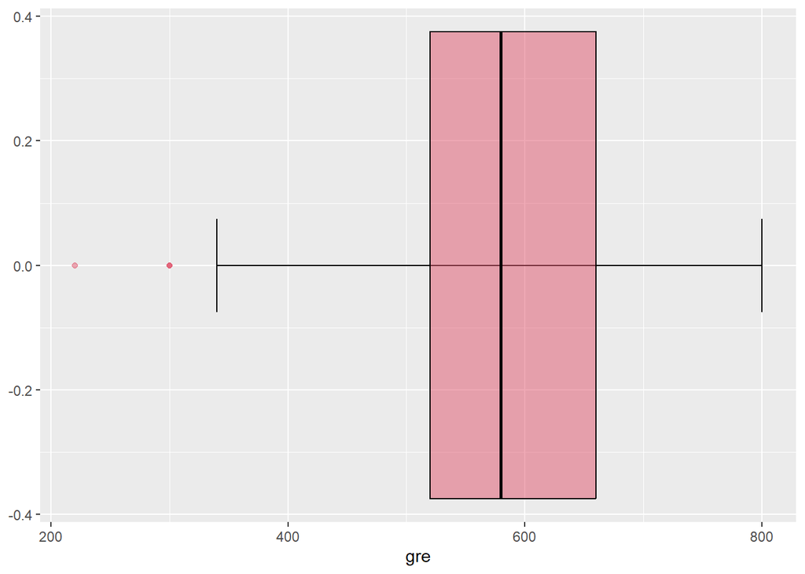

```r
fig(6,2)
ggplot(college_data_copydf, aes(x = gre)) +
  stat_boxplot(geom = "errorbar",
               width = 0.15,
               color = 1) +  # Error bar color
  geom_boxplot(fill = 2,           # Box color
               alpha = 0.5,        # Transparency
               color = 1,          # Border color
               outlier.colour = 2) # Outlier color
```

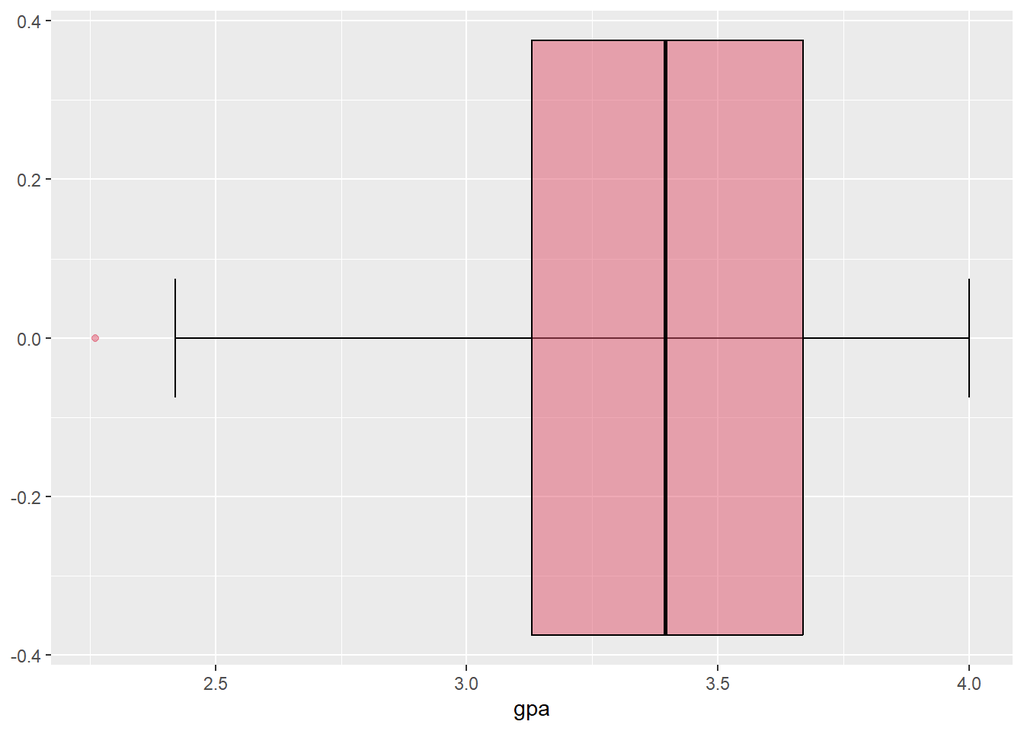

```r
fig(6,2)
ggplot(college_data_copydf, aes(x = gpa)) +
  stat_boxplot(geom = "errorbar",
               width = 0.15,
               color = 1) +  # Error bar color
  geom_boxplot(fill = 2,           # Box color
               alpha = 0.5,        # Transparency
               color = 1,          # Border color
               outlier.colour = 2) # Outlier color
```

#### Task: Use variable reduction techniques to identify significant variables.

```r
#calculate principal components
pca_college_data <- prcomp(college_data[, names(college_data) != "admit"],
                           center = TRUE,scale = TRUE)

pca_college_data
```

```
## Standard deviations (1, .., p=6):
## [1] 1.193405625555005 1.043684719438526 1.016197149455047 0.973264092731320
## [5] 0.955059067902740 0.771017350881461
##
## Rotation (n x k) = (6 x 6):
##                              PC1                 PC2                 PC3
## gre          0.68883320842989171 -0.0320147813750895 -0.0230258389296571
## gpa          0.66171218893977213  0.1875512176944506 -0.0961206132982298
## ses         -0.04857238633419284 -0.2062530796140594 -0.8195750637731024
## Gender_Male  0.00705521536394166 -0.5200838557556554  0.5052177537468618
## Race        -0.00524310552934723  0.7227309732120303  0.2168332344547917
## rank        -0.29190622987373110  0.3583740852892008 -0.1275371436755620
##                             PC4                 PC5                  PC6
## gre         -0.1142245968379014 -0.1428379265720221 -0.70035972449099126
## gpa         -0.2402197176572979  0.0357054219230003  0.67730492213107762
## ses         -0.1464828234606919  0.5037797227919212 -0.09025452128016621
## Gender_Male -0.5109293947099302  0.4616908945342988  0.00327104615337317
## Race         0.0459269455751692  0.6290519180741563 -0.18110825126877433
## rank        -0.8028897062787221 -0.3400935794056484 -0.09898243145040919
```

```r
summary(pca_college_data)
```

```
## Importance of components:
##                                  PC1           PC2           PC3            PC4
## Standard deviation     1.19340562556 1.04368471944 1.01619714946 0.973264092731
## Proportion of Variance 0.23737000000 0.18155000000 0.17211000000 0.157870000000
## Cumulative Proportion  0.23737000000 0.41892000000 0.59103000000 0.748900000000
##                                   PC5            PC6
## Standard deviation     0.955059067903 0.771017350881
## Proportion of Variance 0.152020000000 0.099080000000
## Cumulative Proportion  0.900920000000 1.000000000000
```

```r
#reverse the signs
pca_college_data$rotation <- -1*pca_college_data$rotation

#display principal components
pca_college_data$rotation
```

```
##                              PC1                 PC2                 PC3
## gre         -0.68883320842989171  0.0320147813750895  0.0230258389296571
## gpa         -0.66171218893977213 -0.1875512176944506  0.0961206132982298
## ses          0.04857238633419284  0.2062530796140594  0.8195750637731024
## Gender_Male -0.00705521536394166  0.5200838557556554 -0.5052177537468618
## Race         0.00524310552934723 -0.7227309732120303 -0.2168332344547917
## rank         0.29190622987373110 -0.3583740852892008  0.1275371436755620
##                             PC4                 PC5                  PC6
## gre          0.1142245968379014  0.1428379265720221  0.70035972449099126
## gpa          0.2402197176572979 -0.0357054219230003 -0.67730492213107762
## ses          0.1464828234606919 -0.5037797227919212  0.09025452128016621
## Gender_Male  0.5109293947099302 -0.4616908945342988 -0.00327104615337317
## Race        -0.0459269455751692 -0.6290519180741563  0.18110825126877433
## rank         0.8028897062787221  0.3400935794056484  0.09898243145040919
```

```r
#calculating total variance explained by each principal component

pc_components = 1:6
explained_var_pc = round(pca_college_data$sdev^2 / sum(pca_college_data$sdev^2) *100,2)
cum_explained_var_pc = cumsum(explained_var_pc)
pc_df <- data.frame(pc_components, explained_var_pc, cum_explained_var_pc)

pc_df
```

```
##   pc_components explained_var_pc cum_explained_var_pc
## 1             1            23.74                23.74
## 2             2            18.15                41.89
## 3             3            17.21                59.10
## 4             4            15.79                74.89
## 5             5            15.20                90.09
## 6             6             9.91               100.00
```

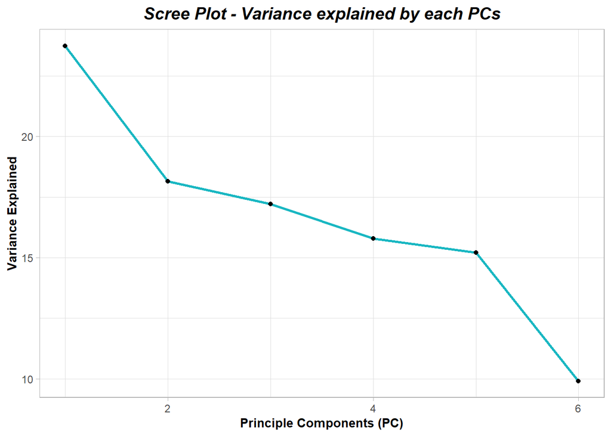

```r
fig(7,4)
ggplot(pc_df, aes(x=pc_components, y=explained_var_pc)) +
  geom_line( color="#00AFBB", size = 1, alpha=0.9, linetype=1) +
  geom_point() +
  ggtitle("Scree Plot - Variance explained by each PCs") +
  xlab("Principle Components (PC)") + ylab("Variance Explained") +
  theme_light() +
  theme(
    plot.title = element_text(color="black", size=14, face="bold.italic", hjust = 0.5),
    axis.title.x = element_text(color="black", size=10, face="bold"),
    axis.title.y = element_text(color="black", size=10, face="bold"))
```

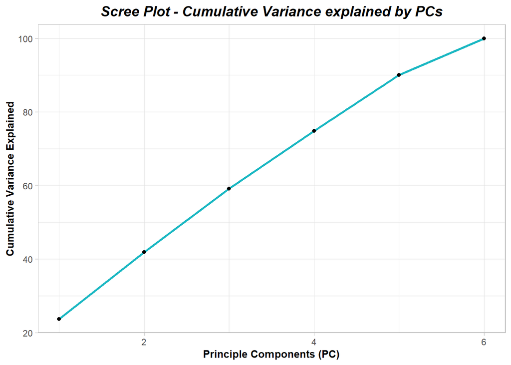

```r
fig(7,4)
ggplot(pc_df, aes(x=pc_components, y=cum_explained_var_pc)) +
  geom_line( color="#00AFBB", size = 1, alpha=0.9, linetype=1) +
  geom_point() +
  ggtitle("Scree Plot - Cumulative Variance explained by PCs") +
  xlab("Principle Components (PC)") + ylab("Cumulative Variance Explained") +
  theme_light() +
  theme(
    plot.title = element_text(color="black", size=14, face="bold.italic", hjust = 0.5),
    axis.title.x = element_text(color="black", size=10, face="bold"),
    axis.title.y = element_text(color="black", size=10, face="bold"))
```

#### Task: Run logistic model to determine the factors that influence the admission process of a student (Drop insignificant variables)

```r
# Splitting dataset

set.seed(24)
split <- sample.split(college_data, SplitRatio = 0.8, )

train_reg <- subset(college_data, split == "TRUE")
test_reg <- subset(college_data, split == "FALSE")

# Training model
classifier_logistic_model  <- glm(admit ~ .,
                                  data = train_reg,
                                  family = "binomial")
classifier_logistic_model
```

```
##
## Call:  glm(formula = admit ~ ., family = "binomial", data = train_reg)
##
## Coefficients:
##       (Intercept)                gre                gpa                ses
## -2.89457254836545   0.00133391333339   0.96058804809996  -0.07763007963117
##       Gender_Male               Race               rank
## -0.31140556954222  -0.15297651370872  -0.58244090227197
##
## Degrees of Freedom: 285 Total (i.e. Null);  279 Residual
## Null Deviance:       354.667772854
## Residual Deviance: 324.490650821     AIC: 338.490650821
```

```r
# Summary
summary(classifier_logistic_model)
```

```
##
## Call:
## glm(formula = admit ~ ., family = "binomial", data = train_reg)
##
## Deviance Residuals:
##             Min               1Q           Median               3Q
## -1.663669092092  -0.850728103591  -0.634602808155   1.142748969200
##             Max
##  2.230443210998
##
## Coefficients:
##                      Estimate        Std. Error  z value   Pr(>|z|)
## (Intercept) -2.89457254836545  1.46086307305005 -1.98141 0.04754502 *
## gre          0.00133391333339  0.00128457100374  1.03841 0.29907851
## gpa          0.96058804809996  0.41408995775291  2.31976 0.02035403 *
## ses         -0.07763007963117  0.16898815121056 -0.45938 0.64596002
## Gender_Male -0.31140556954222  0.27136223707892 -1.14756 0.25114854
## Race        -0.15297651370872  0.16560988269251 -0.92372 0.35563415
## rank        -0.58244090227197  0.15198176148635 -3.83231 0.00012695 ***
## ---
## Signif. codes:  0 '***' 0.001 '**' 0.01 '*' 0.05 '.' 0.1 ' ' 1
##
## (Dispersion parameter for binomial family taken to be 1)
##
##     Null deviance: 354.6677728539  on 285  degrees of freedom
## Residual deviance: 324.4906508214  on 279  degrees of freedom
## AIC: 338.4906508214
##
## Number of Fisher Scoring iterations: 4
```

Dropping insignificant variables and re-running the model

```r
classifier_logistic_model <- glm(admit ~ gre + gpa + rank,
                                 data = train_reg,
                                 family = "binomial")
classifier_logistic_model
```

```
##
## Call:  glm(formula = admit ~ gre + gpa + rank, family = "binomial",
##     data = train_reg)
##
## Coefficients:
##     (Intercept)              gre              gpa             rank
## -3.397393667691   0.001380865353   0.919106447365  -0.576733742022
##
## Degrees of Freedom: 285 Total (i.e. Null);  282 Residual
## Null Deviance:       354.667772854
## Residual Deviance: 326.773061301     AIC: 334.773061301
```

```r
summary(classifier_logistic_model)
```

```
##
## Call:
## glm(formula = admit ~ gre + gpa + rank, family = "binomial",
##     data = train_reg)
##
## Deviance Residuals:
##             Min               1Q           Median               3Q
## -1.521147377925  -0.878379789285  -0.632843358501   1.130938106177
##             Max
##  2.178371953545
##
## Coefficients:
##                      Estimate        Std. Error  z value   Pr(>|z|)
## (Intercept) -3.39739366769143  1.39442882286681 -2.43641 0.01483406 *
## gre          0.00138086535300  0.00127651615843  1.08175 0.27936572
## gpa          0.91910644736457  0.40811834497680  2.25206 0.02431857 *
## rank        -0.57673374202220  0.15074679119692 -3.82584 0.00013032 ***
## ---
## Signif. codes:  0 '***' 0.001 '**' 0.01 '*' 0.05 '.' 0.1 ' ' 1
##
## (Dispersion parameter for binomial family taken to be 1)
##
##     Null deviance: 354.6677728539  on 285  degrees of freedom
## Residual deviance: 326.7730613006  on 282  degrees of freedom
## AIC: 334.7730613006
##
## Number of Fisher Scoring iterations: 4
```

#### Task: Calculate the accuracy of the model and run validation techniques.

```r
# Predict test data based on model

predict_reg_train <- predict(classifier_logistic_model,
                            train_reg, type = "response")

predict_reg_test <- predict(classifier_logistic_model,
                       test_reg, type = "response")


# Changing probabilities
predict_reg_train <- ifelse(predict_reg_train >0.5, 1, 0)
predict_reg_test <- ifelse(predict_reg_test >0.5, 1, 0)

# using confusion matrix
conf_matrix <- confusionMatrix(table(predicted = predict_reg_test,
                                     actual = test_reg$admit),
                                     positive = "1")

conf_matrix
```

```
## Confusion Matrix and Statistics
##
##          actual
## predicted  0  1
##         0 71 31
##         1  5  7
##
##                Accuracy : 0.684210526316
##                  95% CI : (0.590510083558, 0.768067390305)
##     No Information Rate : 0.666666666667
##     P-Value [Acc > NIR] : 0.386795878832
##
##                   Kappa : 0.142857142857
##
##  Mcnemar's Test P-Value : 3.09085937646e-05
##
##             Sensitivity : 0.1842105263158
##             Specificity : 0.9342105263158
##          Pos Pred Value : 0.5833333333333
##          Neg Pred Value : 0.6960784313725
##              Prevalence : 0.3333333333333
##          Detection Rate : 0.0614035087719
##    Detection Prevalence : 0.1052631578947
##       Balanced Accuracy : 0.5592105263158
##
##        'Positive' Class : 1
##
```

```r
train_missing_classerr <- mean(predict_reg_train != train_reg$admit)
train_acc = round((1 - train_missing_classerr)*100,2)
print(paste('Train Accuracy = ', train_acc,'%', sep = '' ))
```

```
## [1] "Train Accuracy = 72.38%"
```

```r
test_missing_classerr <- mean(predict_reg_test != test_reg$admit)
test_acc = round((1 - test_missing_classerr)*100,2)
print(paste('Test Accuracy = ', test_acc,'%', sep = '' ))
```

```
## [1] "Test Accuracy = 68.42%"
```

```r
Logistic_Model_list <- list('Logistic_Classifier', train_acc, test_acc) # storing it for later use
```

#### Task: Try other modelling techniques like decision tree and SVM and select a champion model. Determine the accuracy rates for each kind of model

Running SVM Classifier

```r
scaled_train_reg = scale(train_reg[-c(1)])
scaled_train_reg <- cbind(scaled_train_reg, train_reg[c(1)])

scaled_test_reg = scale(test_reg[-c(1)])
scaled_test_reg <- cbind(scaled_test_reg, test_reg[c(1)])

classifier_svm = svm(formula = admit ~ gre + gpa + rank,
                 data = scaled_train_reg,
                 type = 'C-classification', kernel = 'linear')
summary(classifier_svm)
```

```
##
## Call:
## svm(formula = admit ~ gre + gpa + rank, data = scaled_train_reg,
##     type = "C-classification", kernel = "linear")
##
##
## Parameters:
##    SVM-Type:  C-classification
##  SVM-Kernel:  linear
##        cost:  1
##
## Number of Support Vectors:  184
##
##  ( 95 89 )
##
##
## Number of Classes:  2
##
## Levels:
##  0 1
```

```r
# Predict test data based on model

predict_reg_train <- predict(classifier_svm, train_reg[c('gre', 'gpa', 'rank')])
predict_reg_test <- predict(classifier_svm, test_reg[c('gre', 'gpa', 'rank')])


# using confusion matrix
conf_matrix <- confusionMatrix(table(predicted = predict_reg_test,
                                     actual = test_reg$admit),
                                     positive = "1")

conf_matrix
```

```
## Confusion Matrix and Statistics
##
##          actual
## predicted  0  1
##         0 76 38
##         1  0  0
##
##                Accuracy : 0.666666666667
##                  95% CI : (0.572258794122, 0.752175770832)
##     No Information Rate : 0.666666666667
##     P-Value [Acc > NIR] : 0.543887670537
##
##                   Kappa : 0
##
##  Mcnemar's Test P-Value : 1.94670606018e-09
##
##             Sensitivity : 0.000000000000
##             Specificity : 1.000000000000
##          Pos Pred Value :            NaN
##          Neg Pred Value : 0.666666666667
##              Prevalence : 0.333333333333
##          Detection Rate : 0.000000000000
##    Detection Prevalence : 0.000000000000
##       Balanced Accuracy : 0.500000000000
##
##        'Positive' Class : 1
##
```

```r
train_missing_classerr <- mean(predict_reg_train != train_reg$admit)
train_acc = round((1 - train_missing_classerr)*100,2)
print(paste('Train Accuracy = ', train_acc,'%', sep = '' ))
```

```
## [1] "Train Accuracy = 68.88%"
```

```r
test_missing_classerr <- mean(predict_reg_test != test_reg$admit)
test_acc = round((1 - test_missing_classerr)*100,2)
print(paste('Test Accuracy = ', test_acc,'%', sep = '' ))
```

```
## [1] "Test Accuracy = 66.67%"
```

```r
SVM_Model_list <- list('SVM_Classifier', train_acc, test_acc)
```

Running Random Forest Classifier

```r
scaled_train_reg$admit <- as.factor(scaled_train_reg$admit)
scaled_test_reg$admit <- as.factor(scaled_test_reg$admit)

classifier_RF = randomForest(admit ~ .,
                             data = scaled_train_reg, ntree = 300)
summary(classifier_RF)
```

```
##                 Length Class  Mode
## call              4    -none- call
## type              1    -none- character
## predicted       286    factor numeric
## err.rate        900    -none- numeric
## confusion         6    -none- numeric
## votes           572    matrix numeric
## oob.times       286    -none- numeric
## classes           2    -none- character
## importance        6    -none- numeric
## importanceSD      0    -none- NULL
## localImportance   0    -none- NULL
## proximity         0    -none- NULL
## ntree             1    -none- numeric
## mtry              1    -none- numeric
## forest           14    -none- list
## y               286    factor numeric
## test              0    -none- NULL
## inbag             0    -none- NULL
## terms             3    terms  call
```

```r
# Predicting the Test set results
y_pred_train = predict(classifier_RF, newdata = scaled_train_reg[-7])
y_pred_test = predict(classifier_RF, newdata = scaled_test_reg[-7])

# Confusion Matrix
conf_matrix <- confusionMatrix(table(predicted = y_pred_test,
                                     actual = scaled_test_reg$admit),
                                     positive = "1")

conf_matrix
```

```
## Confusion Matrix and Statistics
##
##          actual
## predicted  0  1
##         0 66 31
##         1 10  7
##
##                Accuracy : 0.640350877193
##                  95% CI : (0.545125092926, 0.728090693509)
##     No Information Rate : 0.666666666667
##     P-Value [Acc > NIR] : 0.75830935864677
##
##                   Kappa : 0.06106870229
##
##  Mcnemar's Test P-Value : 0.00178728903699
##
##             Sensitivity : 0.1842105263158
##             Specificity : 0.8684210526316
##          Pos Pred Value : 0.4117647058824
##          Neg Pred Value : 0.6804123711340
##              Prevalence : 0.3333333333333
##          Detection Rate : 0.0614035087719
##    Detection Prevalence : 0.1491228070175
##       Balanced Accuracy : 0.5263157894737
##
##        'Positive' Class : 1
##
```

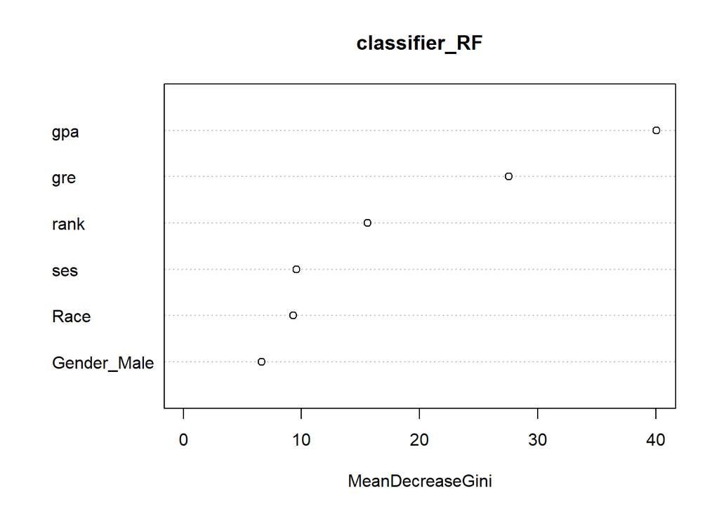

```r
# Variable importance plot
varImpPlot(classifier_RF)
```

```r
train_missing_classerr <- mean(y_pred_train != scaled_train_reg$admit)
train_acc = round((1 - train_missing_classerr)*100,2)
print(paste('Train Accuracy = ', train_acc,'%', sep = '' ))
```

```
## [1] "Train Accuracy = 100%"
```

```r
test_missing_classerr <- mean(y_pred_test != scaled_test_reg$admit)
test_acc = round((1 - test_missing_classerr)*100,2)
print(paste('Test Accuracy = ', test_acc,'%', sep = '' ))
```

```
## [1] "Test Accuracy = 64.04%"
```

```r
RandomForest_Model_list <- list('RandomForest_Classifier', train_acc, test_acc)
```

Running KNN Classifier

```r
classifier_knn <- knn3(formula = admit ~ .,
                       data = scaled_train_reg,
                       k = 3)
classifier_knn
```

```
## 3-nearest neighbor model
## Training set outcome distribution:
##
##   0   1
## 197  89
```

```r
# Determining best K

train_knn_acc <- vector()
test_knn_acc <- vector()

for (n in seq(3,150,2)) {
  classifier_knn <- knn3(formula = admit ~ .,
                         data = scaled_train_reg,
                         k = n)

  train_pred = predict(classifier_knn, scaled_train_reg[-c(7)], type = "class")
  test_pred = predict(classifier_knn, scaled_test_reg[-c(7)], type = "class")


  misClassError_train <- mean(train_pred != scaled_train_reg$admit)
  misClassError_test <- mean(test_pred != scaled_test_reg$admit)

  train_acc = round((1-misClassError_train)*100,2)
  test_acc = round((1-misClassError_test)*100,2)

  train_knn_acc <- append(train_knn_acc, train_acc)
  test_knn_acc <- append(test_knn_acc, test_acc)

}
```

```r
knn_acc_df <- data.frame(K_value = seq(3,150,2),
                         knn_train_accuracy = train_knn_acc,
                         knn_test_accuracy = test_knn_acc)

head(knn_acc_df)
```

```
##   K_value knn_train_accuracy knn_test_accuracy
## 1       3              81.12             63.16
## 2       5              76.57             60.53
## 3       7              73.08             68.42
## 4       9              71.33             65.79
## 5      11              73.43             66.67
## 6      13              72.38             68.42
```

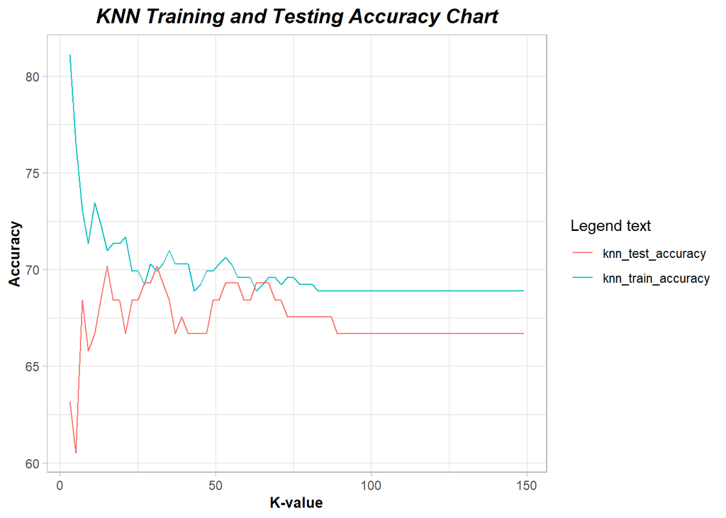

```r
fig(7,4)
ggplot(knn_acc_df, aes(x=K_value)) +
  geom_line(aes(y = knn_train_accuracy, colour = "knn_train_accuracy")) +
  geom_line(aes(y = knn_test_accuracy, colour = "knn_test_accuracy")) +
  #geom_point() +
  ggtitle("KNN Training and Testing Accuracy Chart") +
  labs(color="Legend text") +
  xlab("K-value") + ylab("Accuracy") +
  theme_light() +
  theme(
    plot.title = element_text(color="black", size=14, face="bold.italic", hjust = 0.5),
    axis.title.x = element_text(color="black", size=10, face="bold"),
    axis.title.y = element_text(color="black", size=10, face="bold"))
```

```r
# Running model again after removing irrelevant features

train_knn_acc <- vector()
test_knn_acc <- vector()


for (n in seq(3,150,2)) {
  classifier_knn <- knn3(formula = admit ~ gre + gpa + rank,
                         data = scaled_train_reg,
                         k = n)

  train_pred = predict(classifier_knn, scaled_train_reg[-c(7)], type = "class")
  test_pred = predict(classifier_knn, scaled_test_reg[-c(7)], type = "class")


  misClassError_train <- mean(train_pred != scaled_train_reg$admit)
  misClassError_test <- mean(test_pred != scaled_test_reg$admit)

  train_acc = round((1-misClassError_train)*100,2)
  test_acc = round((1-misClassError_test)*100,2)

  train_knn_acc <- append(train_knn_acc, train_acc)
  test_knn_acc <- append(test_knn_acc, test_acc)

}
```

```r
knn_acc_df <- data.frame(K_value = seq(3,150,2),
                         knn_train_accuracy = train_knn_acc,
                         knn_test_accuracy = test_knn_acc)
head(knn_acc_df)
```

```
##   K_value knn_train_accuracy knn_test_accuracy
## 1       3              79.02             61.40
## 2       5              74.48             67.54
## 3       7              73.43             66.67
## 4       9              72.73             70.18
## 5      11              73.78             69.30
## 6      13              72.38             68.42
```

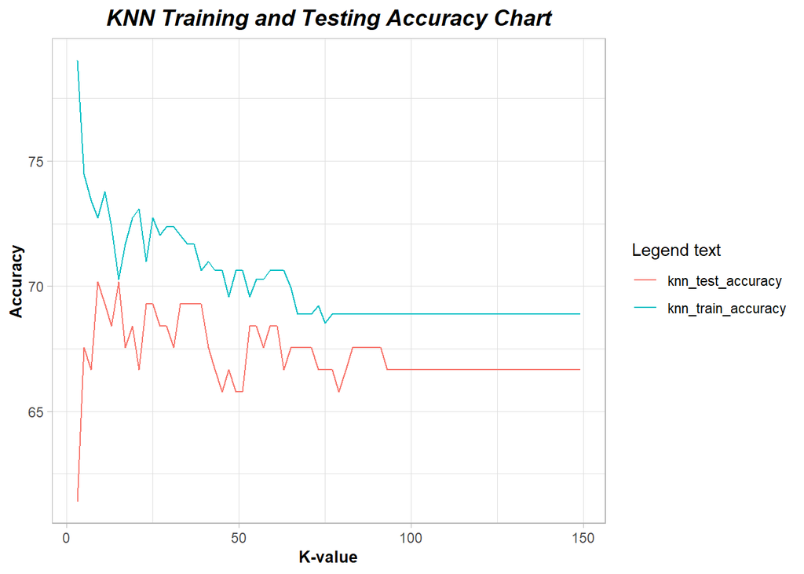

```r
fig(7,4)
ggplot(knn_acc_df, aes(x=K_value)) +
  geom_line(aes(y = knn_train_accuracy, colour = "knn_train_accuracy")) +
  geom_line(aes(y = knn_test_accuracy, colour = "knn_test_accuracy")) +
  #geom_point() +
  ggtitle("KNN Training and Testing Accuracy Chart") +
  labs(color="Legend text") +
  xlab("K-value") + ylab("Accuracy") +
  theme_light() +
  theme(
    plot.title = element_text(color="black", size=14, face="bold.italic", hjust = 0.5),
    axis.title.x = element_text(color="black", size=10, face="bold"),
    axis.title.y = element_text(color="black", size=10, face="bold"))
```

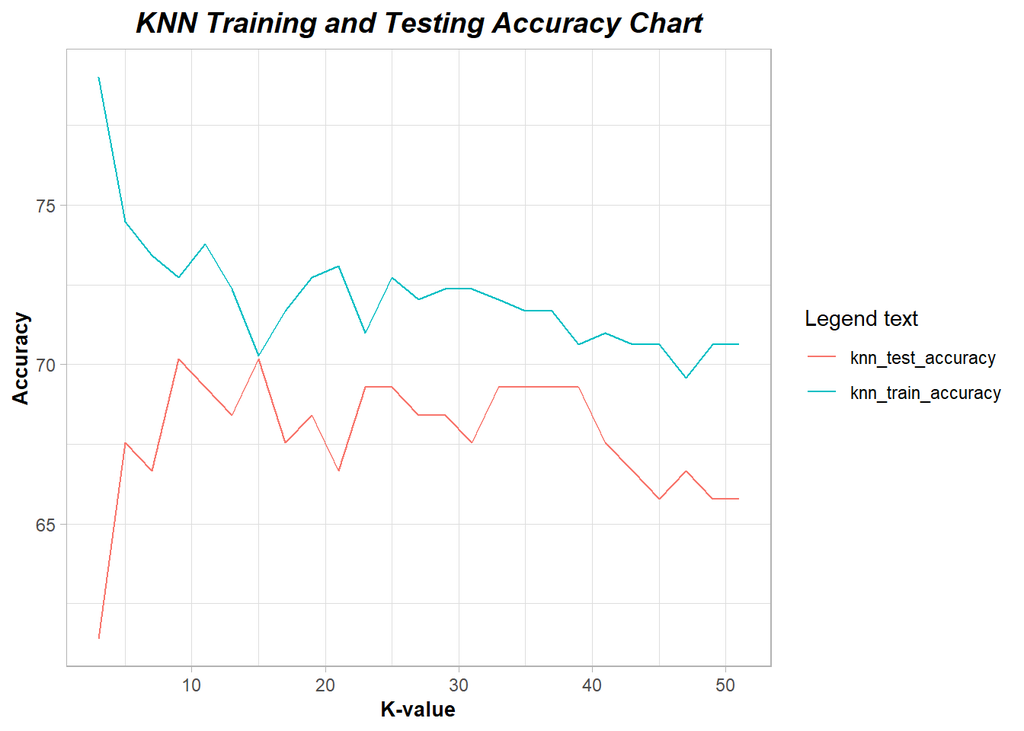

```r
# Zooming

knn_acc_df_subset <- head(knn_acc_df, 25)


fig(7,4)
ggplot(knn_acc_df_subset, aes(x=K_value)) +
  geom_line(aes(y = knn_train_accuracy, colour = "knn_train_accuracy")) +
  geom_line(aes(y = knn_test_accuracy, colour = "knn_test_accuracy")) +
  #geom_point() +
  ggtitle("KNN Training and Testing Accuracy Chart") +
  labs(color="Legend text") +
  xlab("K-value") + ylab("Accuracy") +
  theme_light() +
  theme(
    plot.title = element_text(color="black", size=14, face="bold.italic", hjust = 0.5),
    axis.title.x = element_text(color="black", size=10, face="bold"),
    axis.title.y = element_text(color="black", size=10, face="bold"))
```

```r
knn_acc_df_subset[knn_acc_df_subset$K_value == 15,]
```

```
##   K_value knn_train_accuracy knn_test_accuracy
## 7      15              70.28             70.18
```

```r
train_acc <- knn_acc_df_subset[knn_acc_df_subset$K_value == 15,'knn_train_accuracy']
test_acc <- knn_acc_df_subset[knn_acc_df_subset$K_value == 15,'knn_test_accuracy']

KNN_Model_list <- list('KNN_Classifier', train_acc, test_acc)
```

```r
# Model Comparison

model_comparison_df = rbind(Logistic_Model_list, SVM_Model_list, RandomForest_Model_list, KNN_Model_list)
colnames(model_comparison_df) <- c("Classifier", 'training_accuracy (in %)', 'test_accuracy (in %)')
rownames(model_comparison_df) <- 1:nrow(model_comparison_df)
model_comparison_df
```

```
##   Classifier                training_accuracy (in %) test_accuracy (in %)
## 1 "Logistic_Classifier"     72.38                    68.42
## 2 "SVM_Classifier"          68.88                    66.67
## 3 "RandomForest_Classifier" 100                      64.04
## 4 "KNN_Classifier"          70.28                    70.18
```

#### Task: Select the most accurate model

```r
# Best Model -> KNN

classifier_knn <- knn3(formula = admit ~ gre + gpa + rank,
                       data = scaled_train_reg,
                       k = 15)

train_pred = predict(classifier_knn, scaled_train_reg[-c(7)], type = "class")
test_pred = predict(classifier_knn, scaled_test_reg[-c(7)], type = "class")

misClassError_train <- mean(train_pred != scaled_train_reg$admit)
misClassError_test <- mean(test_pred != scaled_test_reg$admit)

train_acc = round((1-misClassError_train)*100,2)
test_acc = round((1-misClassError_test)*100,2)


conf_matrix <- confusionMatrix(table(predicted = test_pred,
                                     actual = scaled_test_reg$admit),
                                     positive = "1")
conf_matrix
```

```
## Confusion Matrix and Statistics
##
##          actual
## predicted  0  1
##         0 73 31
##         1  3  7
##
##                Accuracy : 0.701754385965
##                  95% CI : (0.608897251529, 0.78382026904)
##     No Information Rate : 0.666666666667
##     P-Value [Acc > NIR] : 0.245293862766
##
##                   Kappa : 0.177419354839
##
##  Mcnemar's Test P-Value : 3.64851094084e-06
##
##             Sensitivity : 0.1842105263158
##             Specificity : 0.9605263157895
##          Pos Pred Value : 0.7000000000000
##          Neg Pred Value : 0.7019230769231
##              Prevalence : 0.3333333333333
##          Detection Rate : 0.0614035087719
##    Detection Prevalence : 0.0877192982456
##       Balanced Accuracy : 0.5723684210526
##
##        'Positive' Class : 1
##
```

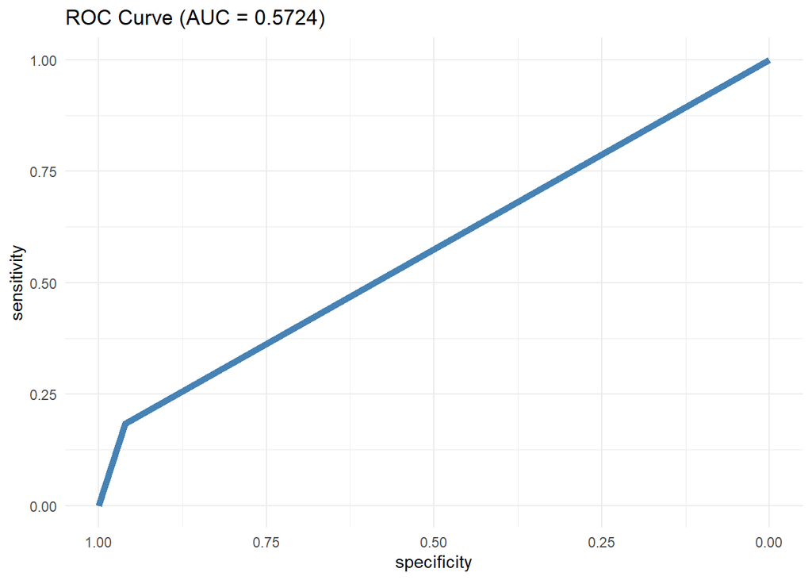

```r
# ROC Curve

#define object to plot and calculate AUC
rocobj <- roc(scaled_test_reg$admit, factor(test_pred, ordered = TRUE))
auc <- round(auc(scaled_test_reg$admit, factor(test_pred, ordered = TRUE)),4)
ggroc(rocobj, colour = 'steelblue', size = 2) +
  ggtitle(paste0('ROC Curve ', '(AUC = ', auc, ')')) +
  theme_minimal()
```

#### Task: Categorize the average of grade point into High, Medium, and Low (with admission probability percentages) and plot it on a point chart.

```r
gre_scores <- college_data[, 'gre']

paste("Min GRE Score: ", min(gre_scores))
```

```
## [1] "Min GRE Score:  220"
```

```r
paste("Max GRE Score: ", max(gre_scores))
```

```
## [1] "Max GRE Score:  800"
```

```r
gre_score_categ <- cut(gre_scores, breaks = c(0,440,580,900), labels = c("Low","Medium","High"))
gre_score_categ[1:10]
```

```
##  [1] Low    High   High   High   Medium High   Medium Low    Medium High
## Levels: Low Medium High
```

```r
college_data$gre_score_category <- gre_score_categ

head(college_data)
```

```
##   admit gre  gpa ses Gender_Male Race rank gre_score_category
## 1     0 380 3.61   1           0    3    3                Low
## 2     1 660 3.67   2           0    2    3               High
## 3     1 800 4.00   2           0    2    1               High
## 4     1 640 3.19   1           1    2    4               High
## 5     0 520 2.93   3           1    2    4             Medium
## 6     1 760 3.00   2           1    1    2               High
```

```r
table(gre_score_categ)
```

```
## gre_score_categ
##    Low Medium   High
##     48    155    197
```

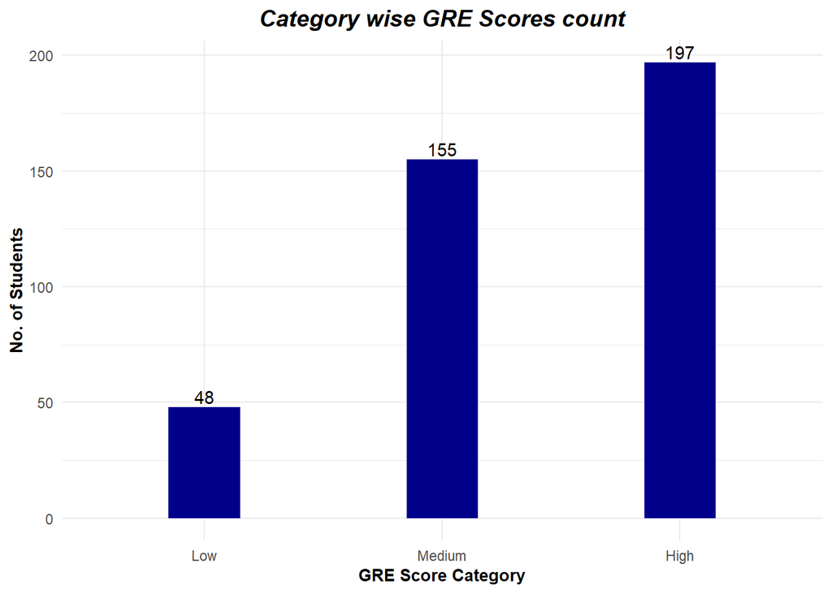

```r
# Bar plot to show category wise GRE Score count of students

fig(7,4)
college_data %>%
  ggplot(aes(x=gre_score_category)) +
  geom_bar(fill = 'darkblue', stat="count", width = 0.3) +
  geom_text(aes(label = after_stat(count)), stat = "count", vjust = -0.25, colour = "black") +
  ggtitle("Category wise GRE Scores count") +
  ylab("No. of Students") + xlab("GRE Score Category") +
  theme_minimal() +
  theme(
    plot.title = element_text(color="black", size=14, face="bold.italic", hjust = 0.5),
    axis.title.x = element_text(color="black", size=10, face="bold"),
    axis.title.y = element_text(color="black", size=10, face="bold"))
```